# Clusteranalysis

```r
library(tableone)
library(tableone)
library(summarytools)
```

Clustermining

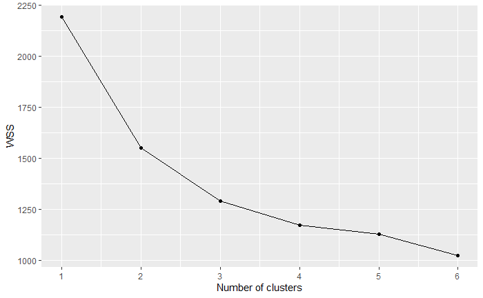

Kmeans Clustering with all time points have 3, 4 and 5 centers

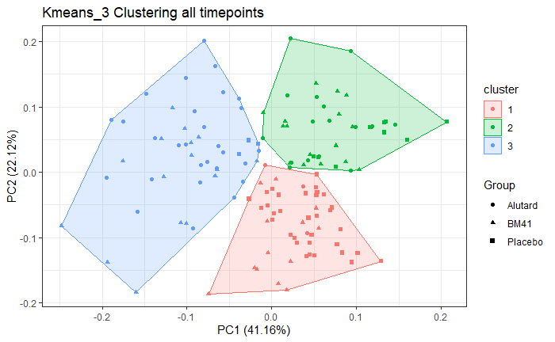

Placebos in all 3 groups visible

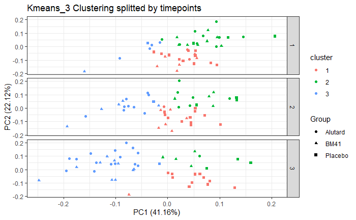

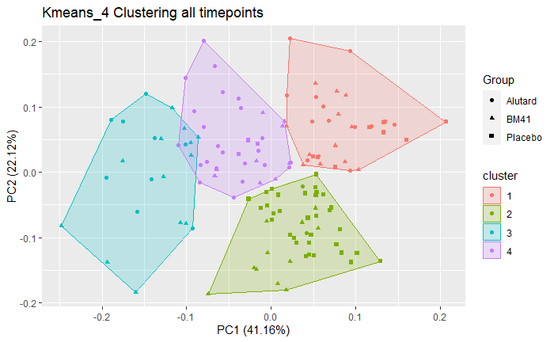

Cluster 3 without Placebos

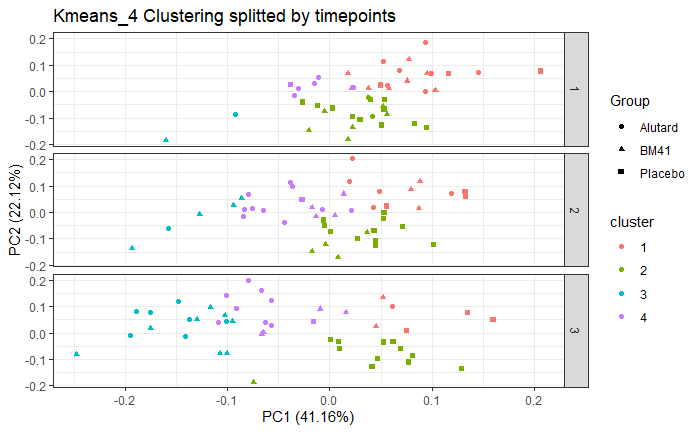

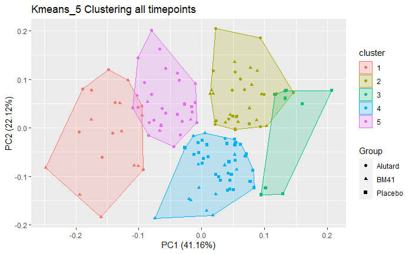

Cluster 1 without placebos Cluster 3 only Placebos

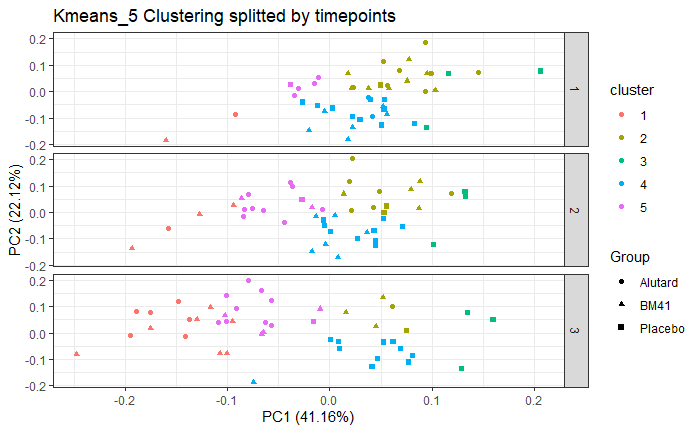

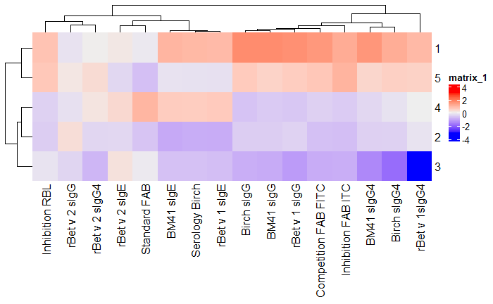

Comparision with the heatmap from the Clusters only at timepoint 3

Biomarker vs. Cluster How they are different in the different Cluster

[figure not shown]

Kmeans Clustering with only Timepoints 2 and 3

```r
#Subset data frame to only include timepoint 3 and 2

set.seed(1234)

df_subset <- df %>%
  filter(Timepoint %in% c('2', '3'))

# Perform kmeans clustering on columns 3:18
kmeans_clusters_3 <- kmeans(df_subset[,3:18], centers = 3)
kmeans_clusters_4 <- kmeans(df_subset[,3:18], centers = 4)
kmeans_clusters_5 <- kmeans(df_subset[,3:18], centers = 5)
```

Plotting the clusters

```r
autoplot(kmeans_clusters_3, frame = TRUE, shape = 'Group', data = df_subset, main= "Kmeans_3 Clustering Timepoint 2 &3")
```

[output not shown]

```r
autoplot(kmeans_clusters_4, frame = TRUE, shape = 'Group', data = df_subset, main= "Kmeans_4 Clustering Timepoint 2 &3")
```

[output not shown]

```r
autoplot(kmeans_clusters_5, frame = TRUE, shape = 'Group', data = df_subset, main= "Kmeans_5 Clustering Timepoint 2 &3")
```

[output not shown]

ANALYSIS OF THE 5 Clusters

BIOMARKER PCA Timepoint 3

```r
# Filter data frame to only include timepoint 3
df_timepoint3 <- df %>%
  filter(Timepoint == 3)

# Perform PCA on columns 3:18
pca_3 <- prcomp(df_timepoint3[,3:18], scale = TRUE)

autoplot(pca_3, data= df, colour= "Group") + theme_bw()
```

[output not shown]

```r
pca.var <- pca_3$sdev^2
pca.var.per <- round(pca.var/sum(pca.var)*100, 1)

barplot(pca.var.per, main="Scree Plot", xlab="Principal Component", ylab="Percent Variation")

loading_scores <- pca_3$rotation[,1]
```

[output not shown]

```r
loading_scores <- pca_3$rotation[,1]

biomarker_scores <- abs(loading_scores) ## get the magnitudes
biomarker_score_ranked <- sort(biomarker_scores, decreasing=TRUE)
top_10_biomarker_PCA3 <- names(biomarker_score_ranked[1:10])

Biomarker <- data.frame(
  Biomarker = top_10_biomarker_PCA3)

View(Biomarker)
```

Biomarker score ranked

1 Birch sIgG 2 rBet v 1 sIgG 3 BM41 sIgG 4 Birch sIgG4 5 BM41 sIgG4 6 Competition FAB FITC 7 Inhibition FAB ITC 8 rBet v 1sIgG4 9 Inhibition RBL 10 Standard FAB

Kmeans Clustering with just timepoint 3

```r
set.seed(1234)
kmeans_clusters_timepoint3_5 <- kmeans(df_timepoint3[,3:18], centers = 5)

autoplot(kmeans_clusters_timepoint3_5, frame = TRUE, shape = 'Group', data = df_timepoint3, main= " Kmeans Clustering Timepoint 3")
```

[output not shown]

```r
Heatmap(kmeans_clusters_timepoint3_5$centers, column_split = 3)
```

[output not shown]